# 김광수_사례연구

#### 하위 소득 10개 직업군을 도표로 출력,시각화

```r
welfare%>%
  filter(!is.na(income))%>%
  group_by(code_job)%>%
  summarise(mean=mean(income),
            sd=sd(income),
            cnt=n())%>%
  arrange(-mean)%>%
  tail(10)
```

```
## # A tibble: 10 x 4
##    code_job  mean    sd   cnt
##       <dbl> <dbl> <dbl> <int>
##  1      953 117.   51.7    59
##  2      952 108.   55.5    92
##  3      421 104.   55.8   115
##  4      991 102.   61.6    16
##  5      611  92    87.1     3
##  6      242  89    NA       1
##  7      941  88.8  82.1   293
##  8      999  88.2  73.7    99
##  9      620  83.3  NA       1
## 10      951  80.2  43.4    91
```

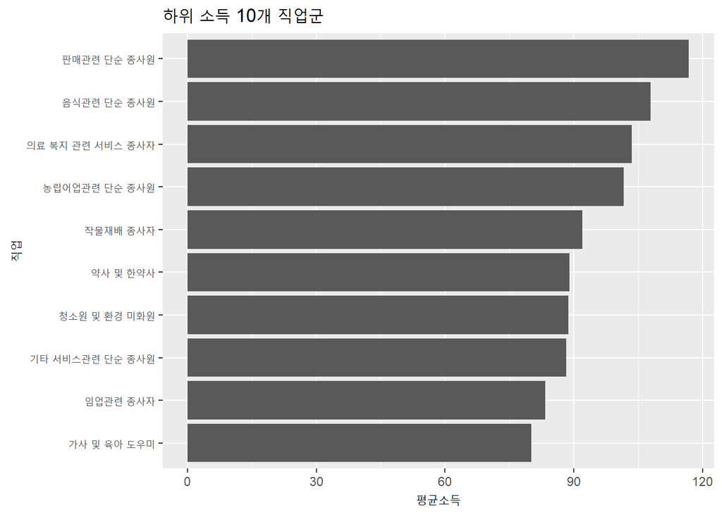

```r
welfare3 <-welfare%>%
  filter(!is.na(income))%>%
  group_by(code_job)%>%
  summarise(mean=mean(income),
            sd=sd(income),
            cnt=n())%>%
  arrange(-mean)%>%
  tail(10)
welfare3$code_job[]=c('판매관련 단순 종사원','음식관련 단순 종사원','의료 복지 관련 서비스 종사자','농립어업관련 단순 종사원','작물재배 종사자','약사 및 한약사','청소원 및 환경 미화원','기타 서비스관련 단순 종사원','임업관련 종사자','가사 및 육아 도우미')

ggplot(welfare3,aes(x=reorder(code_job,mean),y=mean))+
  geom_bar(stat="identity")+
  coord_flip()+
  labs(title="하위 소득 10개 직업군",
       x= "직업",
       y= "평균소득")
```

## 문8

### 1번 문제의 결과인 data.frame변수를 이용하여 성별로 어떤 직업이 가장 많을지 분석하시오.

#### 여성 최빈 직업 상위 10

```r
welfare%>%
  filter(gender=='female')%>%
  group_by(code_job)%>%
  summarise(n=n())%>%
  arrange(-n)%>%
  head(11)
```

```
## # A tibble: 11 x 2
##    code_job     n
##       <dbl> <int>
##  1       NA  5584
##  2      611   680
##  3      941   228
##  4      521   221
##  5      930   185
##  6      313   176
##  7      442   149
##  8      441   126
##  9      951   125
## 10      421   121
## 11      952   104
```

```r
# NA제외
fjob<-welfare%>%
  filter(gender=='female' & !is.na(code_job))%>%
  group_by(code_job)%>%
  summarise(n=n())%>%
  arrange(-n)%>%
  head(10)
fjob$code_job[] <- c('작물재배 종사자','청소원 및 환경 미화원','매장 판매 종사자','제조관련 단순 종사원','화계 및 경리 사무원','음식서비스 종사자','주방장 및 조리사','가사 및 육아 도우미','의료 복지 관련 서비스 종사자','음식관련 단순 종사원')

fjob
```

```
## # A tibble: 10 x 2
##    code_job                         n
##    <chr>                        <int>
##  1 작물재배 종사자                680
##  2 청소원 및 환경 미화원          228
##  3 매장 판매 종사자               221
##  4 제조관련 단순 종사원           185
##  5 화계 및 경리 사무원            176
##  6 음식서비스 종사자              149
##  7 주방장 및 조리사               126
##  8 가사 및 육아 도우미            125
##  9 의료 복지 관련 서비스 종사자   121
## 10 음식관련 단순 종사원           104
```

#### 남성 최빈 직업 상위 10

```r
welfare%>%
  filter(gender=='male')%>%
  group_by(code_job)%>%
  summarise(n=n())%>%
  arrange(-n)%>%
  head(11)
```

```
## # A tibble: 11 x 2
##    code_job     n
##       <dbl> <int>
##  1       NA  3551
##  2      611   640
##  3      873   251
##  4      312   213
##  5      510   141
##  6      521   132
##  7      930   104
##  8      941    97
##  9      910    95
## 10      942    95
## 11      311    92
```

```r
# NA제외
mjob<-welfare%>%
  filter(gender=='male' & !is.na(code_job))%>%
  group_by(code_job)%>%
  summarise(n=n())%>%
  arrange(-n)%>%
  head(10)
mjob$code_job<- c('작물재배 종사자','자동차 운전원','경영관련 사무원','영업 종사자','매장 판매 종사자','제조관련 단순 종사원','청소원 및 환경 미화원','건설 및 광업 단순 종사원','경비원 및 검표원','행정사무원')

mjob
```

```
## # A tibble: 10 x 2
##    code_job                     n
##    <chr>                    <int>
##  1 작물재배 종사자            640
##  2 자동차 운전원              251
##  3 경영관련 사무원            213
##  4 영업 종사자                141
##  5 매장 판매 종사자           132
##  6 제조관련 단순 종사원       104
##  7 청소원 및 환경 미화원       97
##  8 건설 및 광업 단순 종사원    95
##  9 경비원 및 검표원            95
## 10 행정사무원                  92
```

## 문9

### 1번 문제의 결과인 data.frame변수를 이용하여 종교 유무에 따른 이혼률을 분석하시오

#### 종교 유무의 빈도를 시각화

```r
table(welfare$religion ,useNA = 'ifany')
```

```
##
##    1    2
## 8047 8617
```

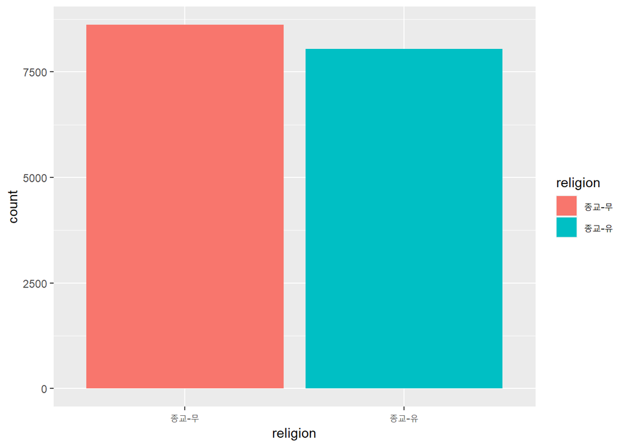

```r
welfare$religion<- ifelse(welfare$religion==1,'종교-유','종교-무')
welfare$religion<- as.factor(welfare$religion)

ggplot(welfare,aes(x=religion))+
  geom_bar(aes(fill=religion))
```

#### 종교 유무에 따른 이혼률 시각화

```r
table(welfare$marriage, useNA = 'ifany')
```

```
##
##    0    1    2    3    4    5    6
## 2861 8431 2117  712   84 2433   26
```

```r
welfare$marriage_group <- ifelse(welfare$marriage==1,'기혼',ifelse(welfare$marriage==3,'이혼',NA))
welfare$marriage_group<-as.factor(welfare$marriage_group)
table(welfare$marriage_group, useNA = 'ifany')
```

```
##
## 기혼 이혼 <NA>
## 8431  712 7521
```

```r
welfare%>%
  filter(!is.na(marriage_group))%>%
  select(marriage_group,religion)%>%
  group_by(religion,marriage_group)%>%
  summarise(total=n())
```

```
## # A tibble: 4 x 3
## # Groups:   religion [2]
##   religion marriage_group total
##   <fct>    <fct>          <int>
## 1 종교-무  기혼            4218
## 2 종교-무  이혼             384
## 3 종교-유  기혼            4213
## 4 종교-유  이혼             328
```

```r
ratiomd<-welfare%>%
  filter(!is.na(marriage_group))%>%
  select(marriage_group,religion)%>%
  group_by(religion,marriage_group)%>%
  summarise(total=n())
ratiomd <- ratiomd%>%
  mutate(percent=(total/sum(total))*100)


ratiomd
```

```
## # A tibble: 4 x 4
## # Groups:   religion [2]
##   religion marriage_group total percent
##   <fct>    <fct>          <int>   <dbl>
## 1 종교-무  기혼            4218   91.7
## 2 종교-무  이혼             384    8.34
## 3 종교-유  기혼            4213   92.8
## 4 종교-유  이혼             328    7.22
```

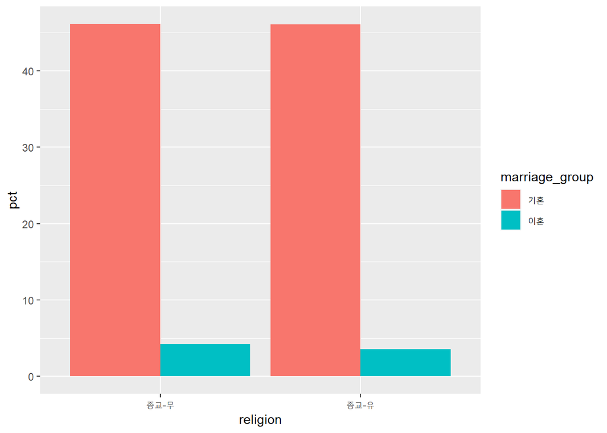

```r
welfare%>%
  filter(!is.na(marriage_group))%>%
  select(marriage_group,religion)%>%
  group_by(religion,marriage_group)%>%
  summarise(pct=n()/sum(table(welfare$marriage_group))*100)%>%
  ggplot(aes(x=religion,y=pct))+
  geom_bar(stat="identity",aes(fill=marriage_group),position = 'dodge')
```

```r
# 종교 유무에 따른 이혼률의 차이는 미비한것으로 보인다.
```

## 문10

### 1번 문제의 결과인 data.frame변수를 이용하여 지역별 연령대 비율을 분석하시오. 노년층이 많은 지역은 어디인지 출력하시오.

#### 지역별 연령대 비율을 분석한 도표 및 그래프를 시각화

```r
table(welfare$code_region, useNA = "ifany")
```

```
##
##    1    2    3    4    5    6    7
## 2486 3711 2785 2036 1467 1257 2922
```

```r
table(welfare$agegrade, useNA = "ifany")
```

```
##
## middle    old  young
##   6210   5871   4583
```

```r
welfare$region <- ifelse(welfare$code_region==1,'서울',ifelse(welfare$code_region==2,'인천/경기',ifelse(welfare$code_region==3,'부산/경남/울산',ifelse(welfare$code_region==4,'대구/경북',ifelse(welfare$code_region==5,'대전/충남',ifelse(welfare$code_region==6,'강원/충북','광주/전남/전북/제주도'))))))
welfare$region<- as.factor(welfare$region)

ratiogr<-welfare%>%
  group_by(region,agegrade)%>%
  summarise(total=n())
ratiogr<-ratiogr%>%
  mutate(percent=(total/sum(total)*100))

#도표
ratiogr
```

```
## # A tibble: 21 x 4
## # Groups:   region [7]
##    region                agegrade total percent
##    <fct>                 <fct>    <int>   <dbl>
##  1 강원/충북             middle     446    35.5
##  2 강원/충북             old        514    40.9
##  3 강원/충북             young      297    23.6
##  4 광주/전남/전북/제주도 middle     991    33.9
##  5 광주/전남/전북/제주도 old       1158    39.6
##  6 광주/전남/전북/제주도 young      773    26.5
##  7 대구/경북             middle     667    32.8
##  8 대구/경북             old        880    43.2
##  9 대구/경북             young      489    24.0
## 10 대전/충남             middle     550    37.5
## # ... with 11 more rows
```

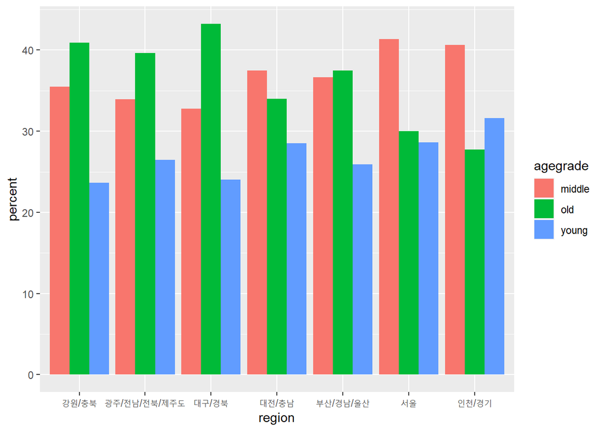

```r
#시각화
ggplot(ratiogr,aes(x=region,y=percent))+
    geom_bar(stat="identity",aes(fill=agegrade),position = "dodge")
```

#### 노년층이 많은 지역이 어디인지 시각화(비율)

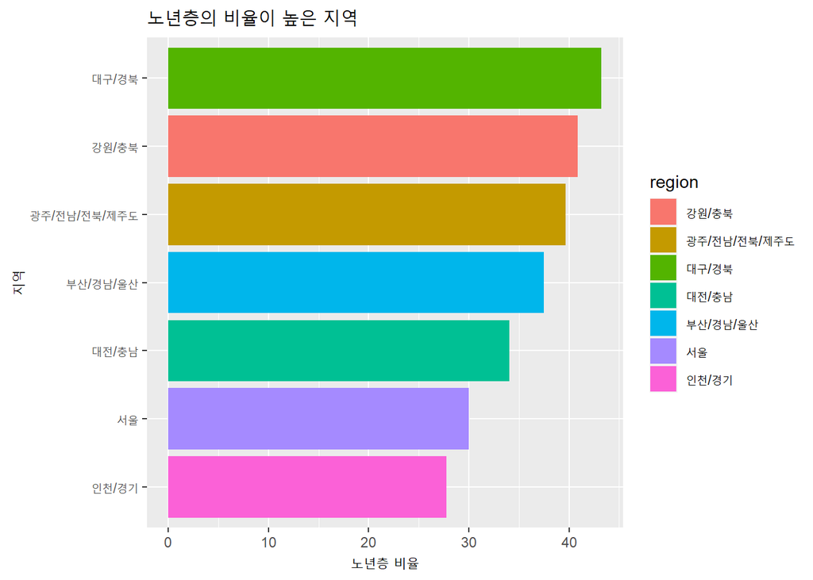

```r
ratiogr%>%
  filter(agegrade=='old')%>%
  arrange(-percent)%>%
  ggplot(aes(x=reorder(region,percent),y=percent,fill=region))+
  geom_bar(stat="identity")+
  coord_flip()+
  labs(title="노년층의 비율이 높은 지역",
         x= "지역",
       y="노년층 비율")
```

#### 노년층이 많은 지역이 어디인지 시각화(개체수)

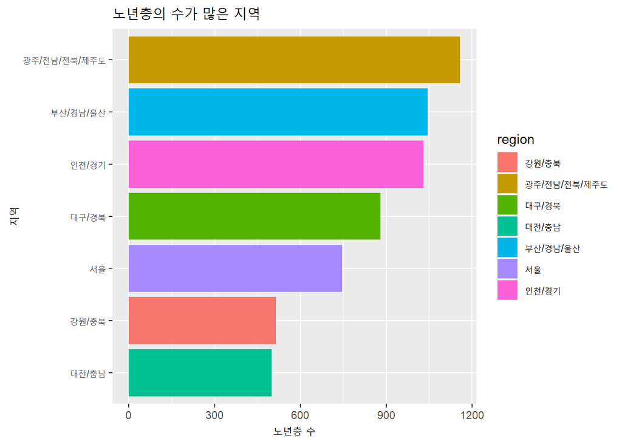

```r
# 노년층 개체가 많은 지역
ratiogr%>%
  filter(agegrade=='old')%>%
  arrange(-total)%>%
  ggplot(aes(x=reorder(region,total),y=total,fill=region))+
  geom_bar(stat="identity")+
  coord_flip()+
  labs(title="노년층의 수가 많은 지역",
       x= "지역",
       y="노년층 수")
```